# Assignment 2 - K-Nearest Neighbour Model

Marketing 2

19 June 2026

# 1. Introduction

This R Markdown document presents the K-Nearest Neighbour model used to predict customer recommendation behaviour for Gelugor Fashion Store. The target variable is `recommend_index`, where customers are classified as either `Recommend` or `Not_Recommend`. The `Not_Recommend` class is treated as the positive class because it represents loyalty-risk customers who may require targeted improvement actions.

# 2. Load Dataset

```r
final_ml_dataset <- read_csv("final_ml_dataset.csv")

dim(final_ml_dataset)
```

```
## [1] 22627   175
```

```r
str(final_ml_dataset)
```

[output not shown]

[output cut: 225 more lines]

[output not shown]

```r
head(final_ml_dataset)
```

```
## # A tibble: 6 × 175
##   recommend_index rating sentiment_score   age alike_feedback_count age_group
##             <dbl>  <dbl>           <dbl> <dbl>                <dbl> <chr>
## 1               1      5               1    40                    0 middle
## 2               1      5               3    62                   12 senior
## 3               0      1               1    47                    3 middle
## 4               1      5               4    45                    0 middle
## 5               1      5              -1    37                    0 middle
## 6               1      4               4    43                    0 middle
## # ℹ 169 more variables: department_name <chr>, class_name <chr>,
## #   feedback_count_group <dbl>, division_name <chr>, amaze <dbl>, fit <dbl>,
## #   jeans <dbl>, pair <dbl>, purchase <dbl>, color <dbl>, fall <dbl>,
## #   flatter <dbl>, lovely <dbl>, model <dbl>, photo <dbl>, shame <dbl>,
## #   soft <dbl>, true <dbl>, unique <dbl>, winter <dbl>, design <dbl>,
## #   love <dbl>, meh <dbl>, black <dbl>, buy <dbl>, perfect <dbl>, size <dbl>,
## #   slightly <dbl>, look <dbl>, odd <dbl>, piece <dbl>, simple <dbl>, …
```

## Target Distribution

```r
table(final_ml_dataset$recommend_index)
```

```
##
##     0     1
##  4101 18526
```

```r
prop.table(table(final_ml_dataset$recommend_index))
```

```
##
##         0         1
## 0.1812436 0.8187564
```

# 3. Data Preparation for KNN

The target variable is converted into a factor with two classes: `Not_Recommend` and `Recommend`. Character predictors are converted into factors. Since KNN is distance-based, categorical predictors will later be converted into dummy variables.

```r
knn_data <- final_ml_dataset %>%
  mutate(
    recommend_index = factor(
      ifelse(recommend_index == 1, "Recommend", "Not_Recommend"),
      levels = c("Not_Recommend", "Recommend")
    ),
    across(where(is.character), as.factor),
    feedback_count_group = as.factor(feedback_count_group)
  )

table(knn_data$recommend_index)
```

```
##
## Not_Recommend     Recommend
##          4101         18526
```

```r
prop.table(table(knn_data$recommend_index))
```

```
##
## Not_Recommend     Recommend
##     0.1812436     0.8187564
```

```r
str(knn_data)
```

```
## tibble [22,627 × 175] (S3: tbl_df/tbl/data.frame)
##  $ recommend_index     : Factor w/ 2 levels "Not_Recommend",..: 2 2 1 2 2 2 2 2 2 2 ...
##  $ rating              : num [1:22627] 5 5 1 5 5 4 5 5 5 5 ...
##  $ sentiment_score     : num [1:22627] 1 3 1 4 -1 4 8 1 5 8 ...
##  $ age                 : num [1:22627] 40 62 47 45 37 43 79 34 49 49 ...
##  $ alike_feedback_count: num [1:22627] 0 12 3 0 0 0 4 2 4 0 ...
##  $ age_group           : Factor w/ 5 levels "adult","elderly",..: 3 4 3 3 3 3 2 1 3 3 ...
##  $ department_name     : Factor w/ 6 levels "Bottoms","Dresses",..: 1 5 1 1 3 5 5 5 5 5 ...
##  $ class_name          : Factor w/ 20 levels "Blouses","Casual bottoms",..: 8 1 16 14 19 18 18 9 5 9 ...
##  $ feedback_count_group: Factor w/ 5 levels "1","2","3","4",..: 1 1 1 1 1 1 1 1 1 1 ...
##  $ division_name       : Factor w/ 3 levels "General","General Petite",..: 1 2 2 2 3 1 1 1 2 1 ...
##  $ amaze               : num [1:22627] 1 0 0 0 0 0 0 0 0 0 ...
##  $ fit                 : num [1:22627] 1 1 0 1 1 0 1 0 0 0 ...
##  $ jeans               : num [1:22627] 1 0 0 0 0 1 0 0 0 0 ...
##  $ pair                : num [1:22627] 1 0 0 0 0 0 0 0 0 0 ...
```

[output cut: 86 more lines]

# 4. Train-Test Split

The dataset is divided into 80% training data and 20% testing data using stratified sampling. This helps preserve the class distribution of `Recommend` and `Not_Recommend` in both datasets.

```r
set.seed(123)

train_index <- createDataPartition(
  knn_data$recommend_index,
  p = 0.8,
  list = FALSE
)

knn_train_raw <- knn_data[train_index, ]
knn_test_raw  <- knn_data[-train_index, ]

dim(knn_train_raw)
```

```
## [1] 18102   175
```

```r
dim(knn_test_raw)
```

```
## [1] 4525  175
```

```r
table(knn_train_raw$recommend_index)
```

```
##
## Not_Recommend     Recommend
##          3281         14821
```

```r
table(knn_test_raw$recommend_index)
```

```
##
## Not_Recommend     Recommend
##           820          3705
```

# 5. Dummy Encoding

KNN requires numeric predictors because it calculates distance between observations. Therefore, categorical variables are converted into dummy variables using `dummyVars()`.

```r
knn_train_predictors <- knn_train_raw %>%
  select(-recommend_index)

knn_test_predictors <- knn_test_raw %>%
  select(-recommend_index)

dummy_model <- dummyVars(
  ~ .,
  data = knn_train_predictors,
  fullRank = TRUE
)

knn_train_x <- predict(dummy_model, newdata = knn_train_predictors) %>%
  as.data.frame()

knn_test_x <- predict(dummy_model, newdata = knn_test_predictors) %>%
  as.data.frame()

colnames(knn_train_x) <- make.names(colnames(knn_train_x), unique = TRUE)
colnames(knn_test_x) <- make.names(colnames(knn_test_x), unique = TRUE)

knn_train_y <- knn_train_raw$recommend_index
knn_test_y  <- knn_test_raw$recommend_index

dim(knn_train_x)
```

```
## [1] 18102   203
```

```r
dim(knn_test_x)
```

```
## [1] 4525  203
```

# 6. Remove Near-Zero Variance Features

Near-zero variance features contain very little useful information and may reduce model stability. These features are removed before training the KNN model.

```r
nzv_cols <- nearZeroVar(knn_train_x)

length(nzv_cols)
```

```
## [1] 146
```

```r
if (length(nzv_cols) > 0) {
  knn_train_x <- knn_train_x[, -nzv_cols, drop = FALSE]
  knn_test_x  <- knn_test_x[, -nzv_cols, drop = FALSE]
}

dim(knn_train_x)
```

```
## [1] 18102    57
```

```r
dim(knn_test_x)
```

```
## [1] 4525   57
```

# 7. KNN Parameter Tuning

A 10-fold cross-validation method is used to tune the KNN model. The number of neighbours, `k`, is tested from 3 to 101 using odd values. The model is optimized based on ROC. Range normalization is applied because KNN is sensitive to differences in variable scale.

```r
knn_control <- trainControl(
  method = "cv",
  number = 10,
  classProbs = TRUE,
  summaryFunction = twoClassSummary,
  savePredictions = "final"
)

knn_grid <- expand.grid(
  k = seq(3, 101, by = 2)
)

set.seed(123)

knn_model <- train(
  x = knn_train_x,
  y = knn_train_y,
  method = "knn",
  metric = "ROC",
  trControl = knn_control,
  tuneGrid = knn_grid,
  preProcess = c("range")
)

print(knn_model)
```

```
## k-Nearest Neighbors
##
## 18102 samples
##    57 predictor
##     2 classes: 'Not_Recommend', 'Recommend'
##
## Pre-processing: re-scaling to [0, 1] (57)
## Resampling: Cross-Validated (10 fold)
## Summary of sample sizes: 16291, 16292, 16292, 16292, 16291, 16292, ...
## Resampling results across tuning parameters:
##
##   k    ROC        Sens       Spec
##     3  0.8272854  0.4937514  0.9508122
##     5  0.8654833  0.4760759  0.9653191
##     7  0.8875835  0.4654126  0.9707171
```

[output cut: 50 more lines]

```r
knn_model$bestTune
```

```
##     k
## 44 89
```

## KNN Tuning Plot

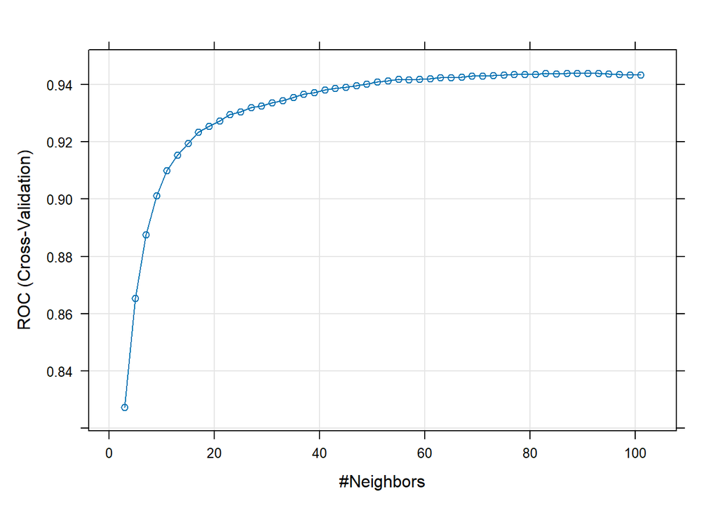

```r
plot(knn_model)
```

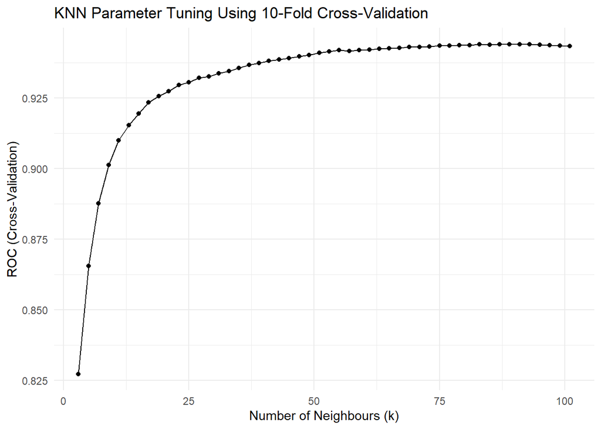

```r
knn_tuning_plot <- ggplot(knn_model$results, aes(x = k, y = ROC)) +
  geom_line() +
  geom_point() +
  labs(
    title = "KNN Parameter Tuning Using 10-Fold Cross-Validation",
    x = "Number of Neighbours (k)",
    y = "ROC (Cross-Validation)"
  ) +
  theme_minimal()

knn_tuning_plot
```

```r
ggsave(
  "KNN_TuningPlot.png",
  knn_tuning_plot,
  width = 7,
  height = 5,
  dpi = 300
)
```

# 8. Test Set Prediction

The trained KNN model is applied to the test dataset. Both predicted classes and predicted probabilities are generated.

```r
knn_pred <- predict(knn_model, newdata = knn_test_x)
knn_prob <- predict(knn_model, newdata = knn_test_x, type = "prob")

head(knn_pred)
```

```
## [1] Recommend Recommend Recommend Recommend Recommend Recommend
## Levels: Not_Recommend Recommend
```

```r
head(knn_prob)
```

```
##   Not_Recommend Recommend
## 1    0.02247191 0.9775281
## 2    0.13186813 0.8681319
## 3    0.02247191 0.9775281
## 4    0.06741573 0.9325843
## 5    0.34831461 0.6516854
## 6    0.15730337 0.8426966
```

# 9. Confusion Matrix

The confusion matrix is used to evaluate how many customers were correctly and incorrectly classified. The positive class is set as `Not_Recommend` because this group represents loyalty-risk customers.

```r
knn_cm <- confusionMatrix(
  data = knn_pred,
  reference = knn_test_y,
  positive = "Not_Recommend"
)

print(knn_cm)
```

```
## Confusion Matrix and Statistics
##
##                Reference
## Prediction      Not_Recommend Recommend
##   Not_Recommend           225        11
##   Recommend               595      3694
##
##                Accuracy : 0.8661
##                  95% CI : (0.8558, 0.8759)
##     No Information Rate : 0.8188
##     P-Value [Acc > NIR] : < 2.2e-16
##
##                   Kappa : 0.3756
##
##  Mcnemar's Test P-Value : < 2.2e-16
##
##             Sensitivity : 0.27439
##             Specificity : 0.99703
##          Pos Pred Value : 0.95339
##          Neg Pred Value : 0.86127
##              Prevalence : 0.18122
##          Detection Rate : 0.04972
##    Detection Prevalence : 0.05215
##       Balanced Accuracy : 0.63571
##
##        'Positive' Class : Not_Recommend
##
```

## Save Confusion Matrix Table

```r
knn_cm_table <- as.data.frame(knn_cm$table)

knn_cm_table
```

```
##      Prediction     Reference Freq
## 1 Not_Recommend Not_Recommend  225
## 2     Recommend Not_Recommend  595
## 3 Not_Recommend     Recommend   11
## 4     Recommend     Recommend 3694
```

```r
write_csv(knn_cm_table, "KNN_ConfusionMatrix_Table.csv")
```

## Confusion Matrix Heatmap

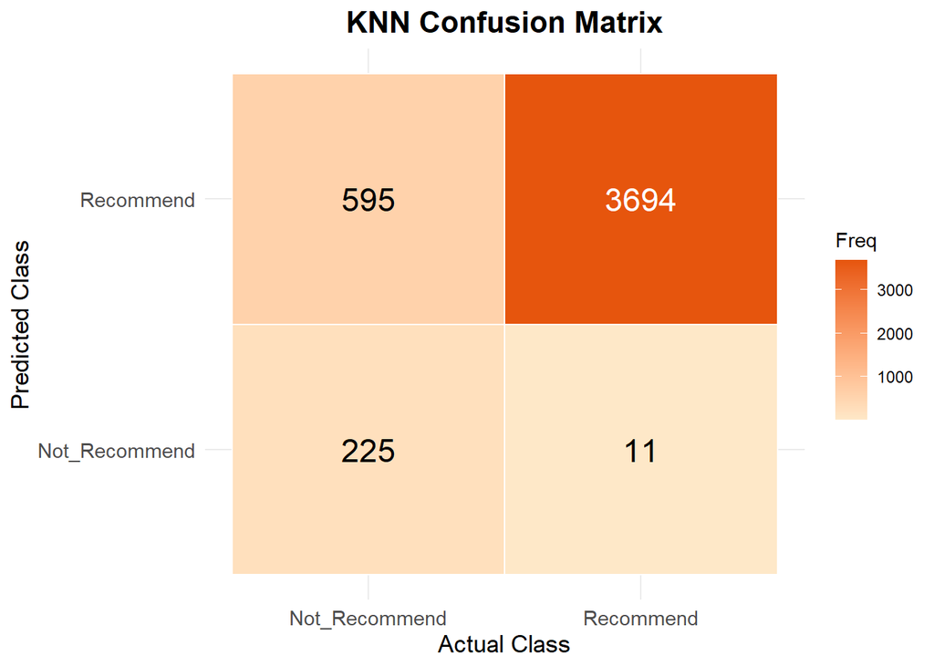

```r
knn_cm_plot <- ggplot(knn_cm_table, aes(x = Reference, y = Prediction, fill = Freq)) +
  geom_tile(color = "white", linewidth = 0.5) +
  geom_text(
    aes(
      label = Freq,
      colour = ifelse(Freq > max(Freq) / 2, "white", "black")
    ),
    size = 6
  ) +
  scale_colour_identity() +
  scale_fill_gradient(
    low = "#FEE8C8",
    high = "#E6550D"
  ) +
  labs(
    title = "KNN Confusion Matrix",
    x = "Actual Class",
    y = "Predicted Class",
    fill = "Freq"
  ) +
  theme_minimal() +
  theme(
    plot.title = element_text(size = 16, face = "bold", hjust = 0.5),
    axis.title = element_text(size = 13),
    axis.text = element_text(size = 11)
  )

knn_cm_plot
```

```r
ggsave(
  "KNN_ConfusionMatrix.png",
  knn_cm_plot,
  width = 6,
  height = 5,
  dpi = 300
)
```

# 10. ROC Curve and AUC

The ROC curve evaluates how well the KNN model separates `Not_Recommend` and `Recommend` customers. A higher AUC value indicates stronger classification separability.

```r
knn_roc <- roc(
  response = knn_test_y,
  predictor = knn_prob$Not_Recommend,
  levels = c("Recommend", "Not_Recommend")
)

knn_auc <- auc(knn_roc)

knn_auc
```

```
## Area under the curve: 0.9475
```

## ROC Curve Plot

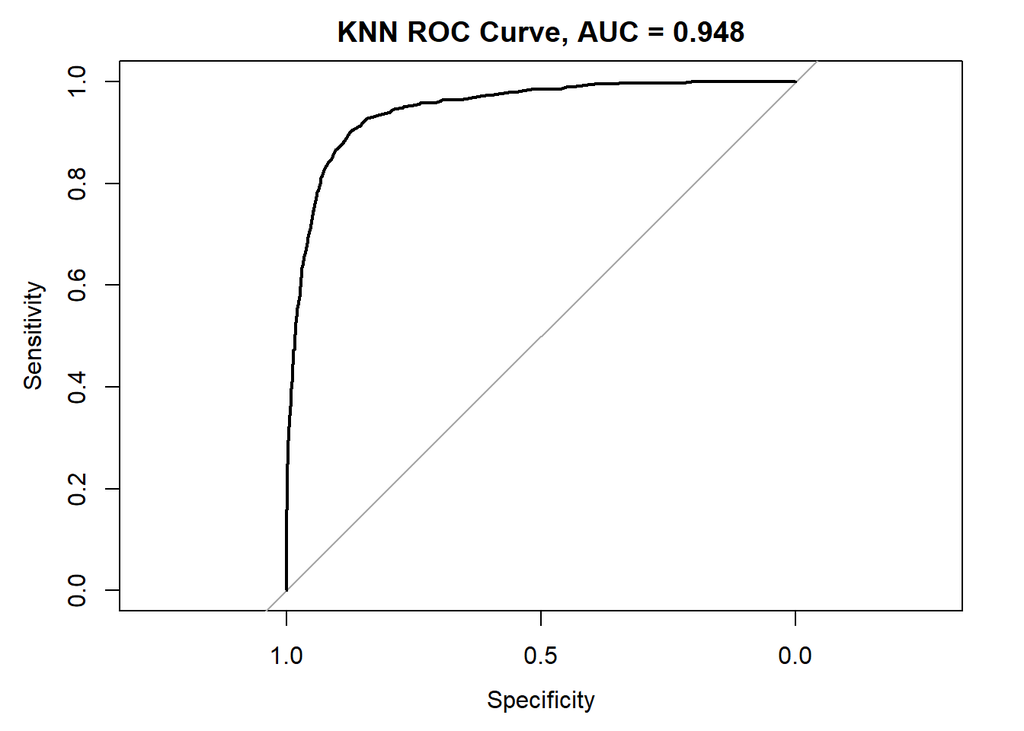

```r
plot(
  knn_roc,
  main = paste("KNN ROC Curve, AUC =", round(knn_auc, 3))
)
```

```r
png("KNN_ROC.png", width = 1000, height = 800, res = 150)

plot(
  knn_roc,
  main = paste("KNN ROC Curve, AUC =", round(knn_auc, 3))
)

dev.off()
```

# 11. Save KNN Performance Metrics

The model performance is summarized using Accuracy, Kappa, Balanced Accuracy, Recall, Specificity, Precision, F1-score and AUC. Since the business focus is identifying loyalty-risk customers, Recall for `Not_Recommend` and Balanced Accuracy are especially important.

```r
knn_metrics <- data.frame(
  Model = "K-Nearest Neighbour",
  Accuracy = as.numeric(knn_cm$overall["Accuracy"]),
  Kappa = as.numeric(knn_cm$overall["Kappa"]),
  Balanced_Accuracy = as.numeric(knn_cm$byClass["Balanced Accuracy"]),
  Recall_NotRecommend = as.numeric(knn_cm$byClass["Sensitivity"]),
  Specificity_Recommend = as.numeric(knn_cm$byClass["Specificity"]),
  Precision_NotRecommend = as.numeric(knn_cm$byClass["Pos Pred Value"]),
  F1_NotRecommend = as.numeric(knn_cm$byClass["F1"]),
  AUC = as.numeric(knn_auc),
  Best_k = knn_model$bestTune$k,
  Removed_NZV_Features = length(nzv_cols)
)

knn_metrics
```

```
##                 Model  Accuracy     Kappa Balanced_Accuracy Recall_NotRecommend
## 1 K-Nearest Neighbour 0.8660773 0.3755579         0.6357106           0.2743902
##   Specificity_Recommend Precision_NotRecommend F1_NotRecommend      AUC Best_k
## 1              0.997031              0.9533898       0.4261364 0.947532     89
##   Removed_NZV_Features
## 1                  146
```

```r
write_csv(knn_metrics, "KNN_Metrics.csv")
```

# 12. Save Final Model

The final KNN model is saved as an RDS file so that it can be reused later for prediction or model deployment.

```r
saveRDS(knn_model, "KNN_Model.rds")
```

# 13. Conclusion

The K-Nearest Neighbour model was developed to predict whether customers would recommend a clothing item. KNN is useful as a distance-based classification model, but its performance depends strongly on scaling, dummy encoding and the selected value of `k`. The final model should be evaluated based on Accuracy, Balanced Accuracy, Recall for `Not_Recommend`, Precision, F1-score and AUC. Since `Not_Recommend` customers represent loyalty-risk customers, the model is especially useful only if it can correctly detect this class.